# Stats 369 - Lab 10

Xinge Tu - xtu424

12/10/2021

## Question 1: Who are the most ‘talkative’ characters in GoT?

Load the dataset and explore the frequency of text sentence by (key) characters.

### Data_in

```r
GoT <- read_csv("Game_of_Thrones_Script.csv")
head(GoT)
```

```
## # A tibble: 6 × 6
##   `Release Date` Season   Episode   `Episode Title`  Name         Sentence
##   <date>         <chr>    <chr>     <chr>            <chr>        <chr>
## 1 2011-04-17     Season 1 Episode 1 Winter is Coming waymar royce What do you e…
## 2 2011-04-17     Season 1 Episode 1 Winter is Coming will         I've never se…
## 3 2011-04-17     Season 1 Episode 1 Winter is Coming waymar royce How close did…
## 4 2011-04-17     Season 1 Episode 1 Winter is Coming will         Close as any …
## 5 2011-04-17     Season 1 Episode 1 Winter is Coming gared        We should hea…
## 6 2011-04-17     Season 1 Episode 1 Winter is Coming royce        Do the dead f…
```

### Top_5 frequency

Find the top 5 characters who say the most lines of texts.

```r
(top_5 = sort(table(GoT$Name), decreasing = TRUE)[1:5])
```

```
##
##   tyrion lannister           jon snow daenerys targaryen   cersei lannister
##               1760               1133               1048               1005
##    jaime lannister
##                945
```

### frequency count change over each season

Use suitable graphs to show their frequency count change over each season.

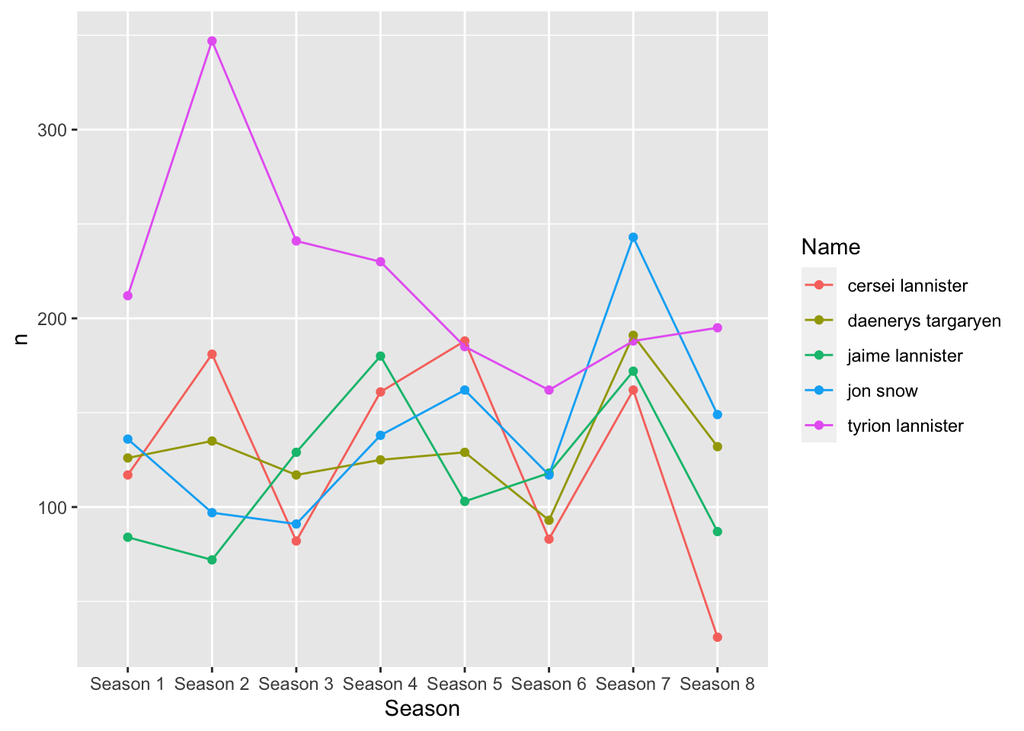

```r
GoT %>% filter(Name %in% names(top_5)) %>% group_by(Season, Name) %>% summarise(n=n()) %>% ggplot(aes(x = Season, y = n, color = Name, group = Name)) + geom_point() + geom_line()
```

## Question 2: What are their sentiments in Season 1?

Use GloVe embedding with glmnet to produce a sentiment score for each word. Roll up the sentiment scores – by taking average over all the words in a sentence – to get an overall sentiment for each line of text. You can then append this ‘Sentiment’ attribute to the raw data set.

Note:

- Before you do the sentiment scoring, you would need to do some text cleaning to extract words from a sentence. For instance, replace special characters such as ‘…’, ‘—’ with space, then do `strsplit` with `split = <blank or punctuations>`.
- You would come across unmatchable words when matching words with GloVe. Most of them would seem like GoT specific, e.g. ‘yunkish’, or ‘Aegon’. You can remove them from the sentiment score calculation.

### Train Semtiment Generator model

```r
con <- dplyr::src_sqlite(file.path('words2.db')) # specify db name
glove <- tbl(con, 'glove') # table name
glove %>% tally() %>% collect()  # check dimension
```

```
## # A tibble: 1 × 1
##         n
##     <int>
## 1 1917494
```

```r
#read in human-classified positive and negative words
pos_words = scan(file = "positive-words.txt", blank.lines.skip = T, comment.char = ";", what = "")
neg_words = scan(file = "negative-words.txt", blank.lines.skip = T, comment.char = ";", what = "")

# bag those into training words. 1: positive; 0: negative
train_words = tibble(words = c(pos_words,neg_words), pos = rep(1:0,c(length(pos_words), length(neg_words))))
train_words = copy_to(con, train_words, name = 'train_words', temporary = TRUE, overwrite = TRUE)

# joining with glove
train.df <- train_words %>%  inner_join(glove, by = c('words' = 'Word')) %>% collect()

# create design matrix for 'glmnet'
train_x <- train.df %>% select(-words, -pos) %>% as.matrix()
rownames(train_x) <- train.df$words

# response
train_y <- train.df$pos

# logistical model with a mix (50/50) mix of L1 and L2 regularisation.
fit <- cv.glmnet(train_x, train_y, family = 'binomial', alpha = 0.5)
```

### Define a Semtiment Generator Function

```r
predict_sentiment <- function(db_con = con, db_name = 'glove', text, model = fit){
  glove <- tbl(db_con, db_name)
  word_tbl <- copy_to(db_con,
                      tibble(words = tolower(strsplit(text,"[[:blank:],.!?;:'\"]")[[1]])),
                      name = "temp_words",
                      overwrite = TRUE,
                      temporary = TRUE)
  word_x <- inner_join(word_tbl, glove, by = c('words' = 'Word')) %>%
    collect() %>%
    select(-words) %>%
    as.matrix()
  if(nrow(word_x) == 0 ) return(0)
  senti <- predict(model$glmnet.fit, word_x, s = model$lambda.min)
  mean(senti)
}
```

### text cleaning for testing set

```r
# text cleaning to extract words from a sentence: ‘…’, ‘—’ with space, then do strsplit(split = " ")
sample_text = sample(length(GoT$Sentence),5)
clean_text =  GoT$Sentence[sample_text] %>% str_replace_all( "-", " ") %>% str_replace_all("…"," ") %>% str_replace_all("\\."," ") %>% str_replace_all("\\,"," ") %>% str_replace_all("\\?"," ") %>% str_replace_all("\\!"," ") %>% as.array() %>% apply(1,str_trim) %>% unique()

result = vector(length = length(clean_text))
for (i in 1:length(clean_text)) {
  result[i] = predict_sentiment(text = clean_text[i])
}

cbind(text = clean_text, score = result) %>% as.data.frame()
```

```
##                                 text              score
## 1                         The others    1.3975851400959
## 2               Unpleasant  I expect  -2.66011235340209
## 3 Your cousin  And the King's squire   2.40809217599364
## 4            They obviously had help  0.758559962356651
## 5                 I don't understand -0.844905006116782
```

Now produce a picture showing the change in sentiments by season 1 episodes for the 5 characters identified from Q1. ### change in sentiments by season 1

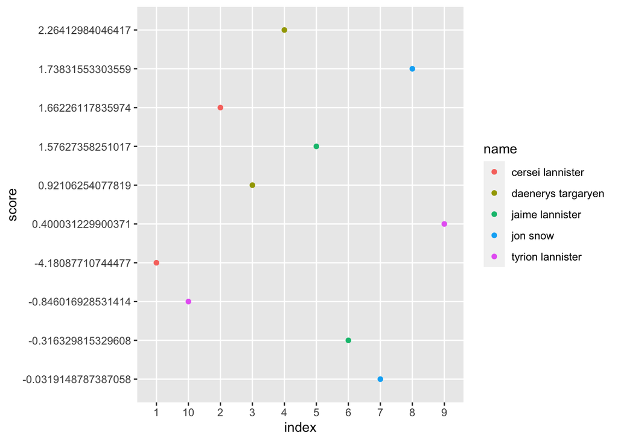

```r
new = GoT %>% filter(Season == "Season 1" & Episode == "Episode 1" & Name %in% names(top_5))
temp = c(sample(which(new$Name=="cersei lannister"),2),
           sample(which(new$Name=="daenerys targaryen"),2),
           sample(which(new$Name=="jaime lannister"),2),
           sample(which(new$Name=="jon snow"),2),
           sample(which(new$Name=="tyrion lannister"),2))
new = new[temp,]
new_text = new$Sentence %>% str_replace_all( "-", " ") %>% str_replace_all("…"," ") %>% str_replace_all("\\."," ") %>% str_replace_all("\\,"," ") %>% str_replace_all("\\?"," ") %>% str_replace_all("\\!"," ") %>% as.array() %>% apply(1,str_trim) %>% unique()

result = vector(length = length(new_text))

for (i in 1:length(new_text)) {
  result[i] = predict_sentiment(text = new_text[i])
}

cbind(index = 1:length(new_text), text = new_text, score = result, name = new$Name) %>% as.data.frame() %>%
  ggplot(aes(x = index, y = score, color = name, group = name)) + geom_point()
```

## Question 3: How does a character’s sentiment evolve over time?

Pick a character from Q1, use the sentiment scores generated from Q2 to make a graph showing the fluctuation of sentiment scores for all the texts associated with that character over each season & episode. Answer the question based on the picture produced.

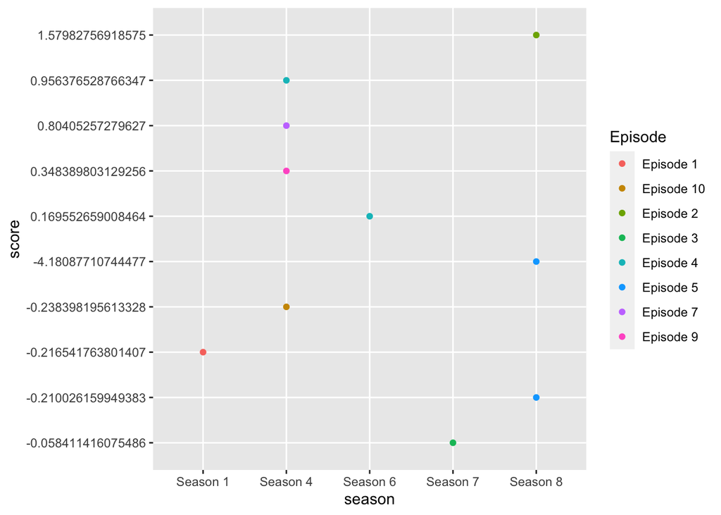

```r
new = GoT %>% filter(Name=="jon snow")
temp = sample(nrow(new), 10)
new = new[temp,]
new_text = new$Sentence %>% str_replace_all( "-", " ") %>% str_replace_all("…"," ") %>% str_replace_all("\\."," ") %>% str_replace_all("\\,"," ") %>% str_replace_all("\\?"," ") %>% str_replace_all("\\!"," ") %>% as.array() %>% apply(1,str_trim) %>% unique()

result = vector(length = length(new_text))

for (i in 1:length(new_text)) {
  result[i] = predict_sentiment(text = new_text[i])
}

cbind(season = new$Season,text = new_text, score = result, Episode = new$Episode) %>% as.data.frame() %>%
  ggplot(aes(x = season, y = score, color = Episode, group = Episode)) + geom_point()
```

## Question 4: What are the most frequently spoken words for a character? Are they of good / bad sentiment?

For the character you chose from Q3, produce a word cloud showing the most frequently used words spoken by that character, colour the words by their sentiment scores (from Q2).

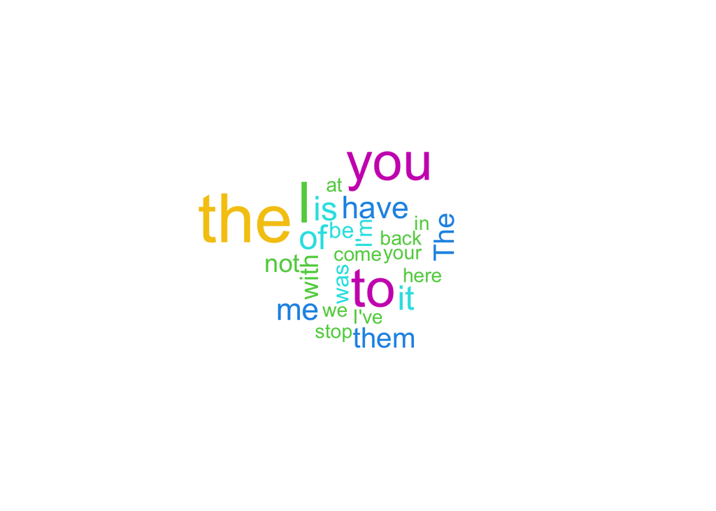

```r
library("wordcloud")
new = GoT %>% filter(Name=="jon snow")
temp = sample(nrow(new),50)
new = new[temp,]
new_text = new$Sentence %>% str_replace_all( "-", " ") %>% str_replace_all("…"," ") %>% str_replace_all("\\."," ") %>% str_replace_all("\\,"," ") %>% str_replace_all("\\?"," ") %>% str_replace_all("\\!"," ") %>% as.array() %>% apply(1,str_trim) %>% unique() %>% strsplit(" ") %>% unlist() %>% table()

d = cbind(word = names(new_text), freq = as.numeric(new_text))[-c(1:21),] %>% as.data.frame()
d$freq = as.numeric(d$freq)
d1 = d %>% filter(freq >= 4)

new_text = d1$word

result = vector(length = length(new_text))

for (i in 1:length(new_text)) {
  result[i] = predict_sentiment(text = new_text[i])
}

d1$score = result

set.seed(1234)
wordcloud(words = d1$word, freq = d1$freq,
          colors= d1$score+3)
```

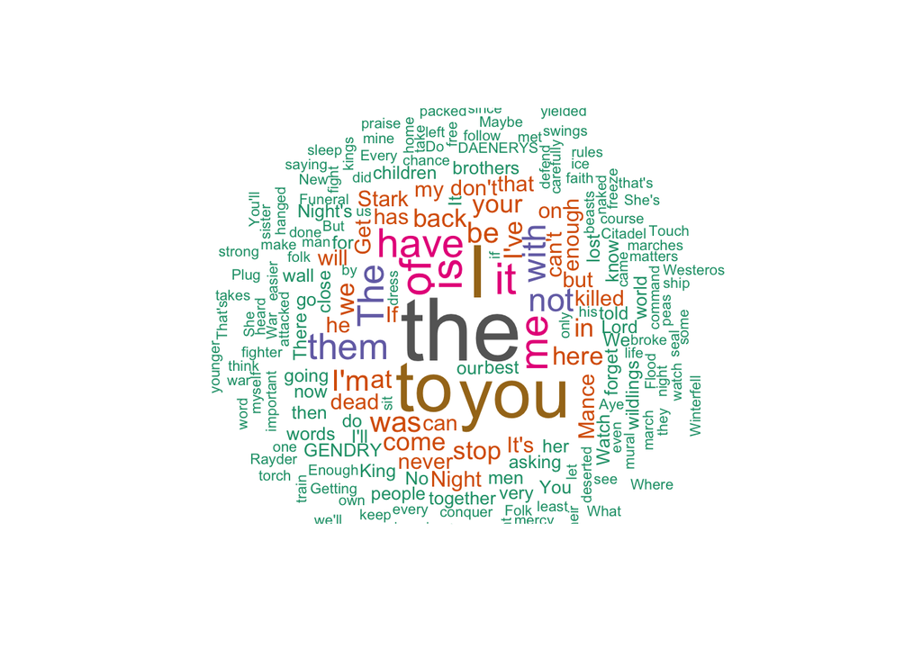

```r
wordcloud(words = d$word, freq = d$freq, min.freq = 1,
          max.words = 200, random.order=FALSE, rot.per=0.35,
          colors=brewer.pal(8, "Dark2"))
```